# R for Humanities: Plotting

[Main Menu](https://htmlpreview.github.io/?https://github.com/argentenum/Rworkshop/blob/master/notebooks/RforHumanities.nb.html)

This lesson will discuss the basics of plotting charts and visualizing data. In this lesson we will learn some basic concepts. You may find more detailed tutorials at [A ggplot2 tutorial for beginners](https://www.sharpsightlabs.com/blog/ggplot2-tutorial/). This tutorial works with the ‘ggplot2’ package. However, before starting on ‘ggplot2’ we should get started with R’s in-built plot functions.

```r
knitr::opts_chunk$set(fig.width=6, fig.height=4)
```

# 1 Plotting points in on a chart

To start let us try to put a point on a chart. - we have to specify the (x,y) coordinates.

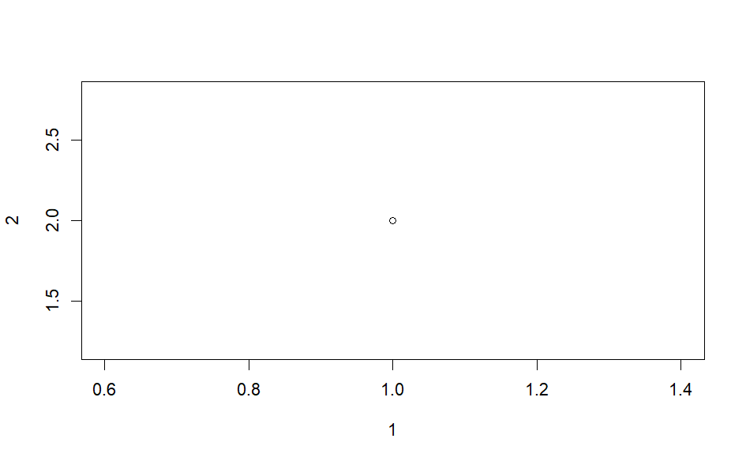

```r
plot(1,2)
```

Using the ‘plot’ function we can also plot a series of points by specifying equal sized vectors for x-axis and y-axis.

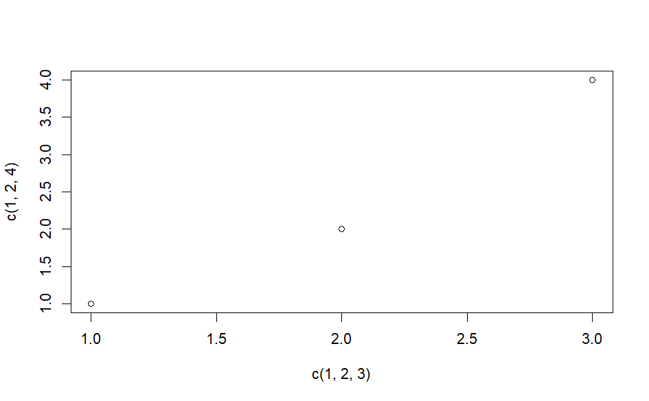

```r
plot(c(1,2,3), c(1,2,4))
```

# 2 Add Axis Labels

We can also change the axis labels.

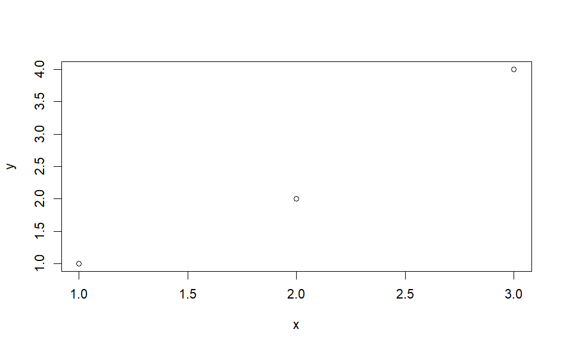

```r
plot(c(1,2,3), c(1,2,4), xlab="x", ylab="y")
```

# 3 Plotting Lines

In this way we can customize the chart by specifying more attribute values:

“l” for lines (the default is “p” for points)

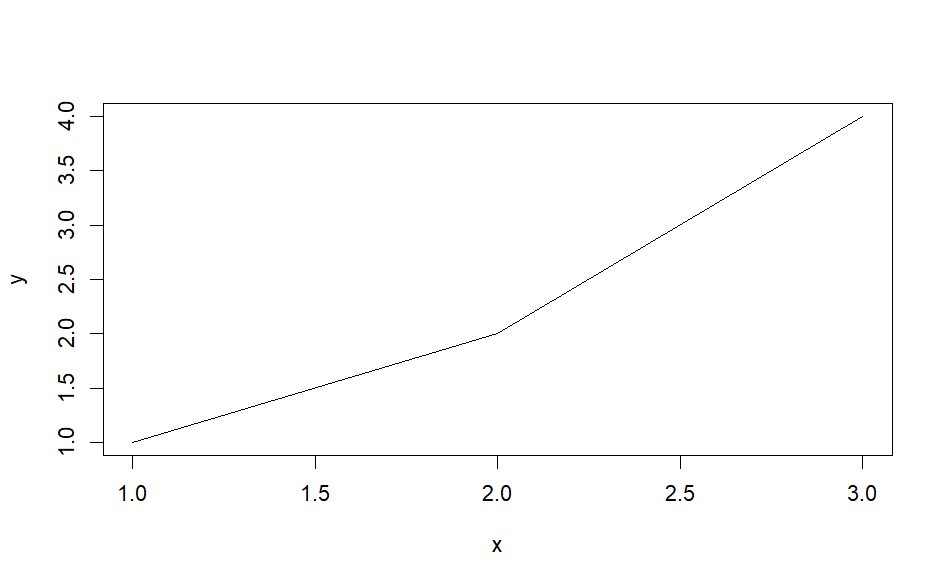

```r
plot(c(1,2,3), c(1,2,4), xlab="x", ylab="y","l")
```

“b” for both lines and points

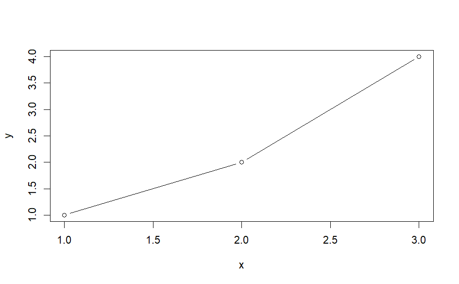

```r
plot(c(1,2,3), c(1,2,4), xlab="x", ylab="y","b")
```

You can examine the full list of attributes by examining ?plot

# 4 Frequency Counts

Let us try our hand at plotting some meaningful data. For this we shall import an in-built R dataset

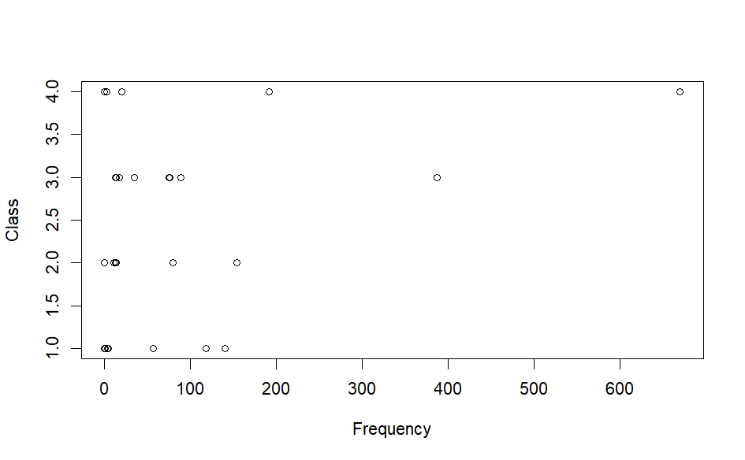

```r
titanicDF <- data.frame(Titanic)
plot(titanicDF$Freq,titanicDF$Class, xlab = "Frequency", ylab = "Class")
```

What we got a scatterplot. Nice, but this is not that meaningful is it? Let us switch the axes.

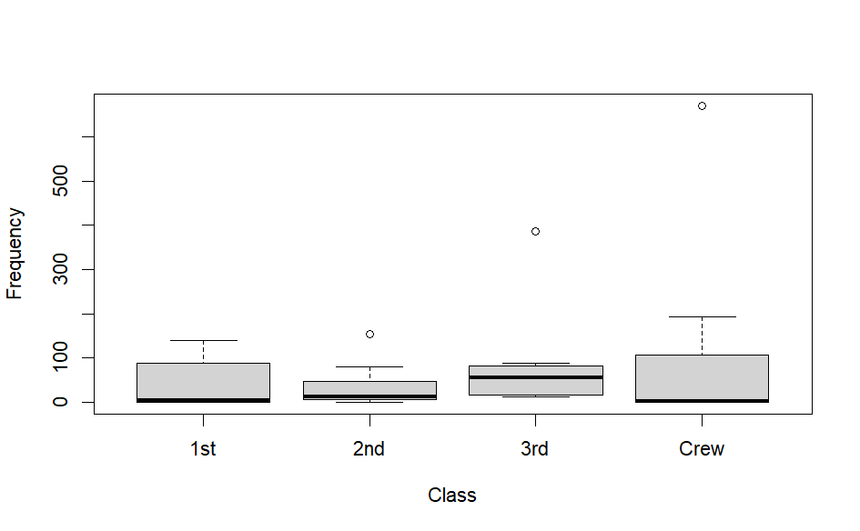

```r
plot(titanicDF$Class,titanicDF$Freq, xlab = "Class", ylab = "Frequency")
```

What we get is a Boxplot. [What is a Boxplot?](https://www.geeksforgeeks.org/box-plot/#what-is-a-box-plot)

So you can see that the power of R as a statistical programming tool is beginning to unfold. R recognizes the shape of the data and automatically pushes it to an appropriate chart.

# 5 piechart

We shall now try our hand at piecharts. First let us create some data.

```r
x <- c(21, 62, 10, 53)
labels <- c("London", "New York", "Singapore", "Mumbai")
```

Now we can call the ‘pie’ function.

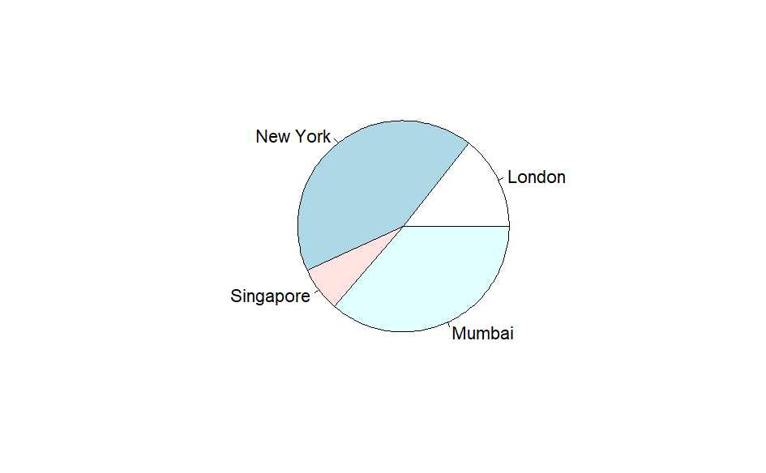

```r
pie(x,labels)
```

We can add some character and colour to the pie.

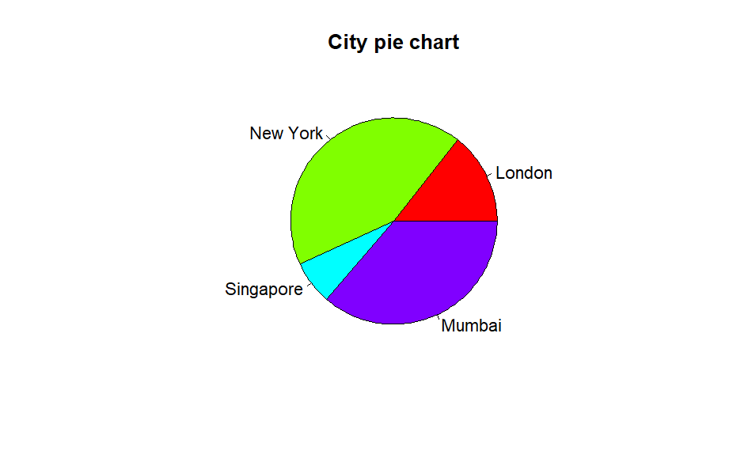

```r
pie(x, labels, main = "City pie chart", col = rainbow(length(x)))
```

Here “rainbow” is one of the [standard colour palettes of R](https://r-charts.com/color-palettes/). “col = rainbow(length(x)” calls the use of the “rainbow” palette and defines its length (ie. number of colours to be used from the origin of the palette) as the length of the Vector “x”.

# 6 Histogram

Let us call one of R’s native datasets.

```r
data(iris)
head(iris)
```

|  | Sepal.Length | Sepal.Width | Petal.Length | Petal.Width | Species |
| --- | --- | --- | --- | --- | --- |
| 1 | 5.1 | 3.5 | 1.4 | 0.2 | setosa |
| 2 | 4.9 | 3.0 | 1.4 | 0.2 | setosa |
| 3 | 4.7 | 3.2 | 1.3 | 0.2 | setosa |
| 4 | 4.6 | 3.1 | 1.5 | 0.2 | setosa |
| 5 | 5.0 | 3.6 | 1.4 | 0.2 | setosa |
| 6 | 5.4 | 3.9 | 1.7 | 0.4 | setosa |

Let us plot a histogram of the Length of the Petals.

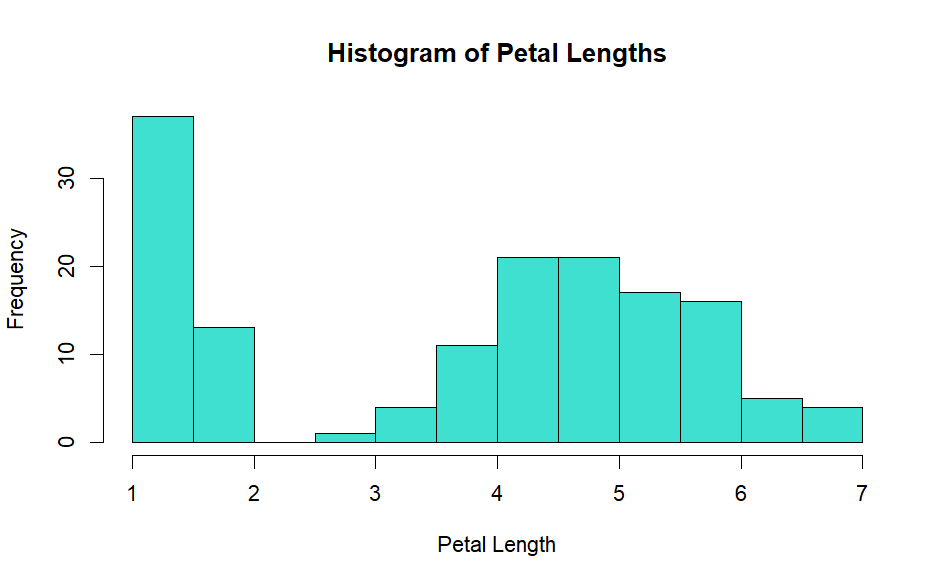

```r
hist(iris$Petal.Length, col = "turquoise", main = "Histogram of Petal Lengths", xlab = "Petal Length")
```

You can further customize the attributed of the ‘hist’ command.

```r
?hist
```

# 7 Bar Plot

For generating a Bar Plot let use R’s native dataset ‘diamonds’.

```r
head(diamonds)
```

| carat | cut | color | clarity | depth | table | price | x | y | z |
| --- | --- | --- | --- | --- | --- | --- | --- | --- | --- |
| 0.23 | Ideal | E | SI2 | 61.5 | 55 | 326 | 3.95 | 3.98 | 2.43 |
| 0.21 | Premium | E | SI1 | 59.8 | 61 | 326 | 3.89 | 3.84 | 2.31 |
| 0.23 | Good | E | VS1 | 56.9 | 65 | 327 | 4.05 | 4.07 | 2.31 |
| 0.29 | Premium | I | VS2 | 62.4 | 58 | 334 | 4.20 | 4.23 | 2.63 |
| 0.31 | Good | J | SI2 | 63.3 | 58 | 335 | 4.34 | 4.35 | 2.75 |
| 0.24 | Very Good | J | VVS2 | 62.8 | 57 | 336 | 3.94 | 3.96 | 2.48 |

We will compute the count for each type of ‘cut’ and thereafter generate a Bar Plot.

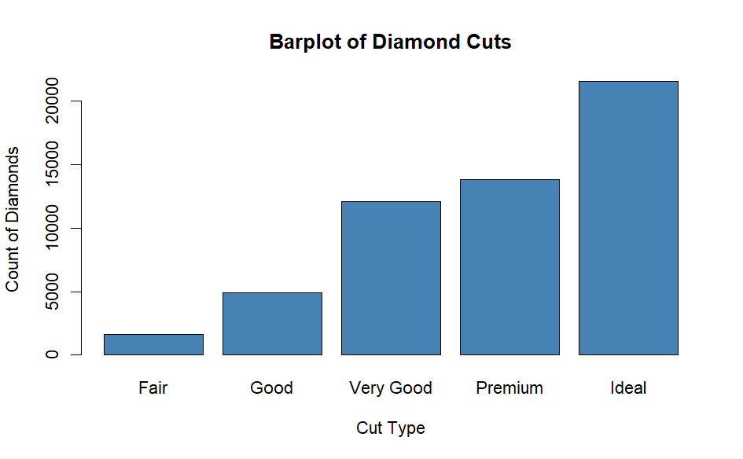

```r
cut_counts <- diamonds %>% count(cut) %>% as.data.frame()
barplot(
  cut_counts$n,         # Counts of the cuts
  names.arg = cut_counts$cut,    # Labels for the cuts
  col = "steelblue",             # Set the color of the bars
  main = "Barplot of Diamond Cuts", # Title of the plot
  xlab = "Cut Type",             # Label for the x-axis
  ylab = "Count of Diamonds"     # Label for the y-axis
)
```

# 8 ggplot2

Ggplot2 is a graphics package for R. It can be used to visualize the results of data analysis.

Install the package ggplot2. Then call it to action.

```r
library(ggplot2)
```

Charts with ggplot2 are structured as layers with each layer adding additional information and features to the layers beneath in order to produce the final graphic. Let us demonstrate with a chart produced through an anaylsis of R’s native dataset ‘diamonds’. In this demonstration you can ignore what the chart is actually demonstrating. Let us just understand the structure of the chart.

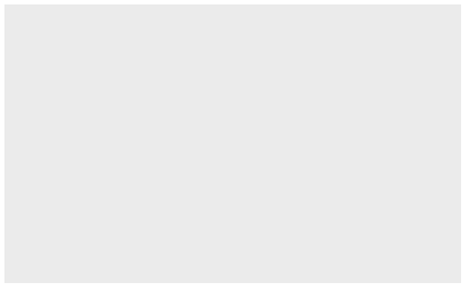

```r
ggplot(diamonds) #this just defines the dataset that we are working with. It could be a dataframe.
```

You will see that the moment we call the ggplot function it create a chart background.

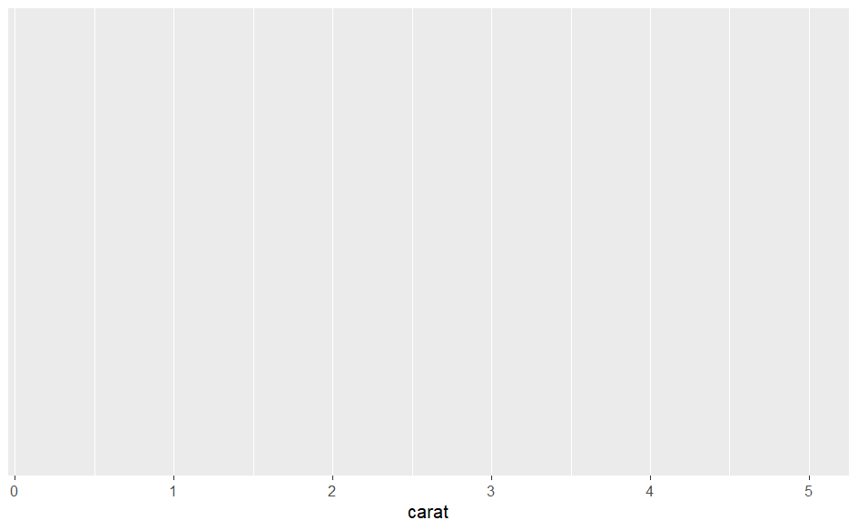

```r
ggplot(diamonds, aes(x=carat))
```

Now let us specify the variables for the y-axis

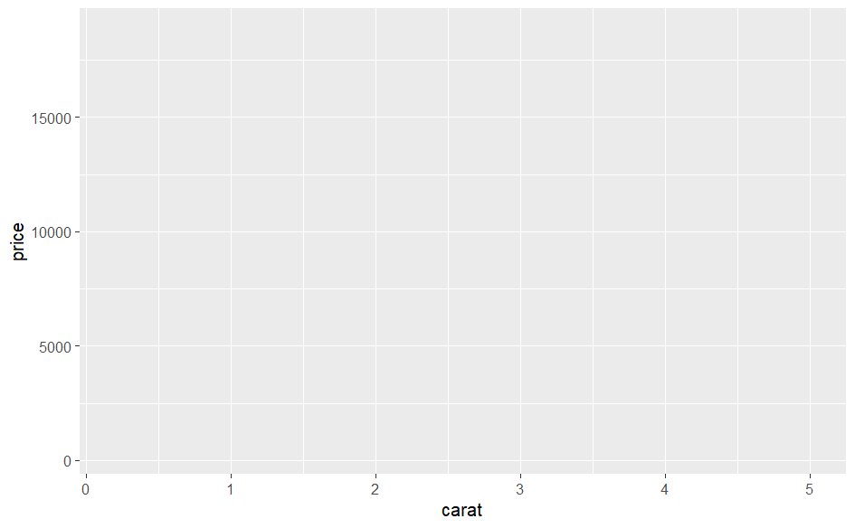

```r
ggplot(diamonds, aes(x=carat, y=price))
```

Thereafter we can add some additional aiesthetic information:

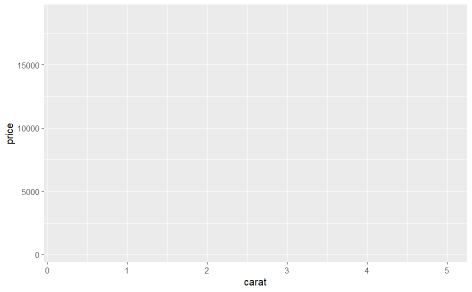

```r
ggplot(diamonds, aes(x=carat, y=price, color=cut))
```

You don’t see any addtion in the above layer. But the command ‘color=cut’ defines that each different factor for the variable ‘cut’ is assigned a different color.

Now we are ready to add some data to the chart and define the type of chart element we want to use to visualize our data. In this case we shall use points for a scatter plot.

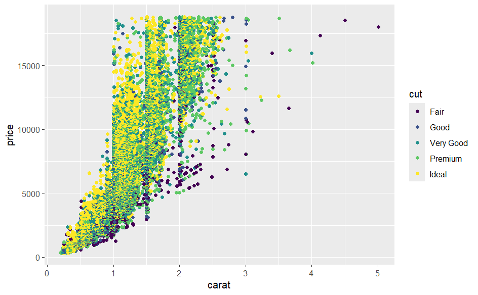

```r
ggplot(diamonds, aes(x=carat, y=price, color=cut)) + geom_point()
```

This the ggplot workflow defines and arranges layer by layer

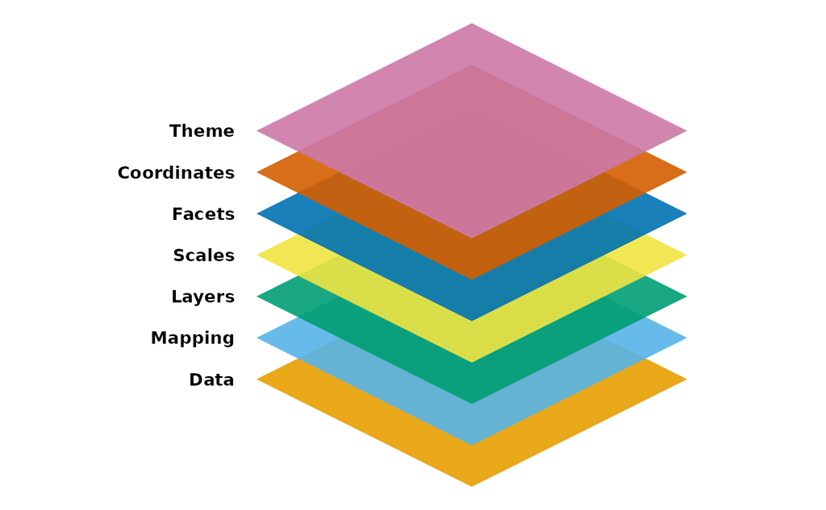

7 composable parts of a ggplot chart

Image courtesy: https://ggplot2.tidyverse.org/articles/ggplot2.html

# 9 Basics of R ggplot syntax

Now these layers translate to different parts and attributes of a single ggplot statement: the function [ggplot()], the data [data =], the aesthetics ie. the indices, color, size etc. [aes()], labels [labs] and the geom ie. the chart type - line, bar, point etc.

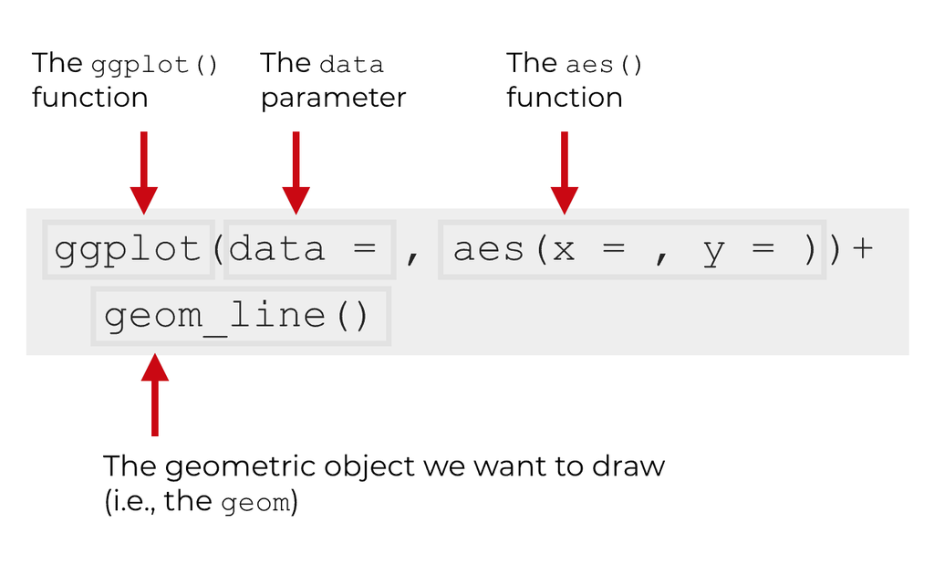

ggplot Syntax

Image courtesy: https://www.sharpsightlabs.com/blog/ggplot2-tutorial/#syntax-of-ggplot2

The elements can be strung together as a single statement. If scripted as a standalone statement it will generate a chart as in the above example. If the statement is assigned to a variable, the variable can be used to call the image when required.

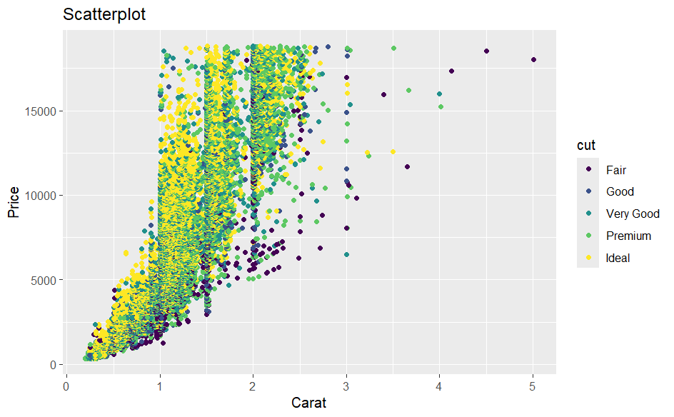

```r
gg <- ggplot(diamonds, aes(x=carat, y=price, color=cut)) +
  geom_point() +
  labs(title="Scatterplot", x="Carat", y="Price")
print(gg)
```

Let us now look at a few more examples.

For the first one we shall use the ‘mtcars’ dataset.

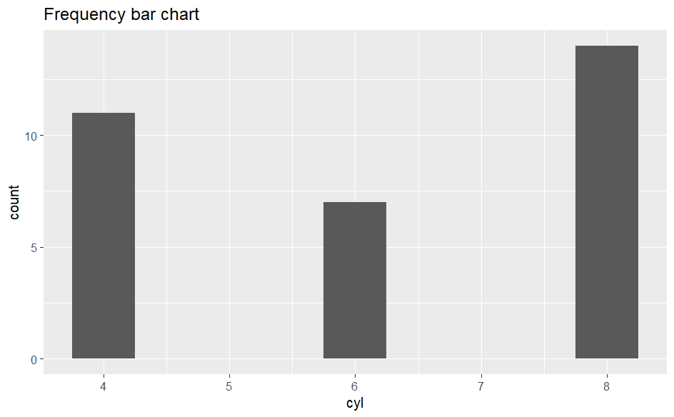

```r
plot1 <- ggplot(mtcars, aes(x=cyl)) + geom_bar(width = 0.5) + labs(title="Frequency bar chart")
print(plot1)
```

This exports a frequency chart of the cars with particular cylinder sizes.

Now let us try to create a dataframe and them visualize it.

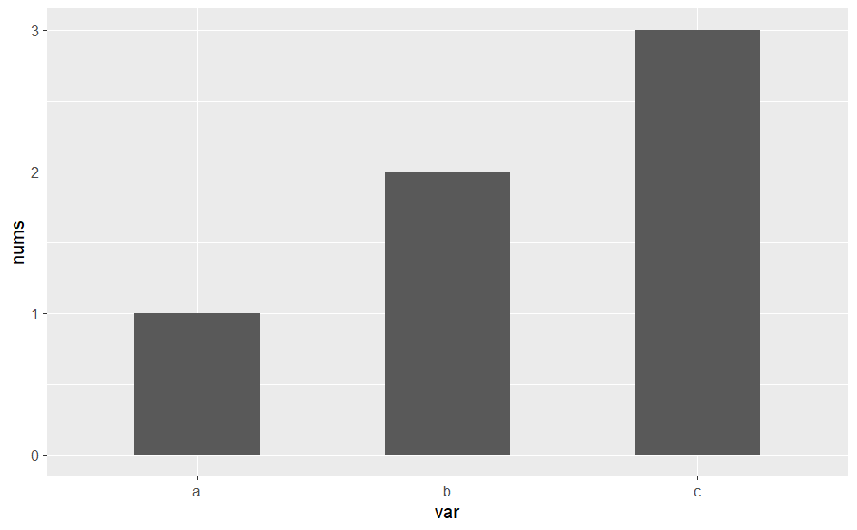

```r
df <- data.frame(var=c("a", "b", "c"), nums=c(1:3))
plot2 <- ggplot(df, aes(x=var, y=nums))+ geom_bar(stat = "identity", width = 0.5)
print(plot2)
```

Thus we see that the x-axis can have string values as well.

Now let us try to examine how particular geometric types work in ggplot. For our examples we shall use the the ‘nile’ dataset in R. ‘Nile’ is a timeseries dataset giving the flow of the Nile between the years 1871 and 1970.

```r
str(Nile)
```

```
 Time-Series [1:100] from 1871 to 1970: 1120 1160 963 1210 1160 1160 813 1230 1370 1140 ...
```

To work with ggplot we need to convert it to a dataframe.

```r
NileDF <- data.frame(c(1871:1970),as.numeric(Nile))
names(NileDF) <- c("Year", "Flow")
```

## 9.1 Line chart

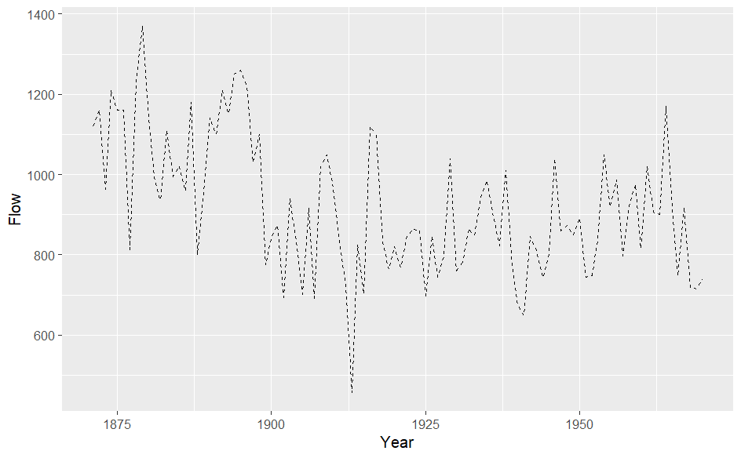

```r
ggplot(data = NileDF, aes(x = Year, y = Flow)) +
  geom_line(linetype = "dashed")
```

## 9.2 Scatter PLot

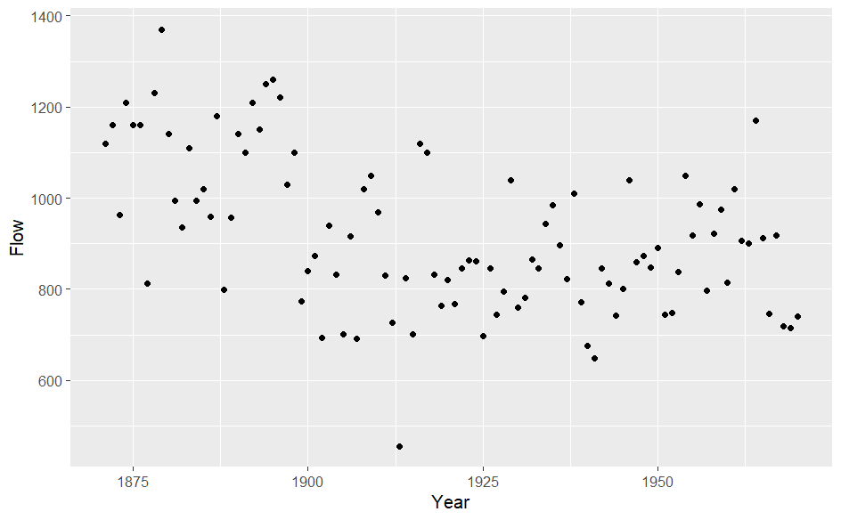

```r
ggplot(data = NileDF, aes(x = Year, y = Flow)) +
  geom_point()
```

## 9.3 Bar Plot

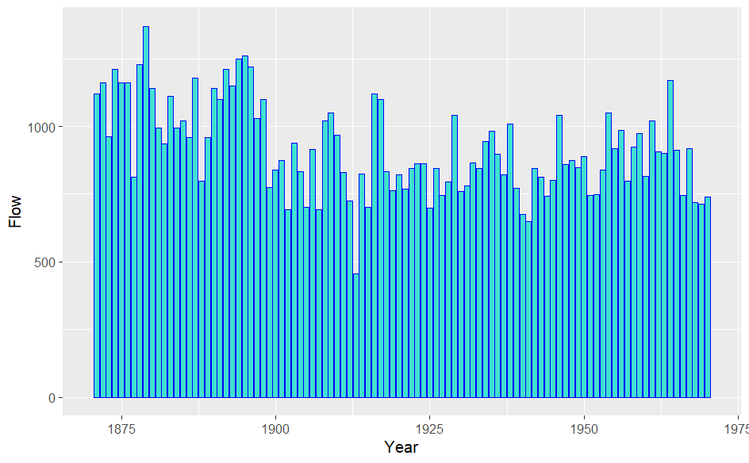

```r
ggplot(data = NileDF, aes(x = Year, y = Flow)) + geom_bar(stat = 'identity', color = "blue", fill = "turquoise")
```

## 9.4 Histogram

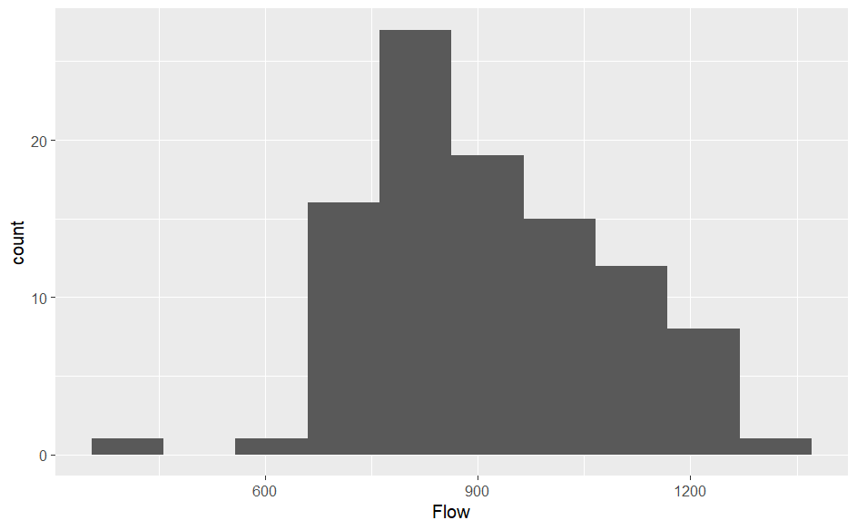

```r
ggplot(data =NileDF, aes(x=Flow)) + geom_histogram(bins = 10)
```

## 9.5 Pie Chart

The data.frame ‘NileDF’ is not formed for pie charts. So, let us recreate the dataset of the kind that was used for creating the pie chart on R’s default packages.

```r
cityDF <- data.frame(c("London", "New York", "Singapore", "Mumbai"),c(21, 62, 10, 53))
names(cityDF) <- c("City","Value")
```

Now we are ready to plot the Pie Chart using ggplot2

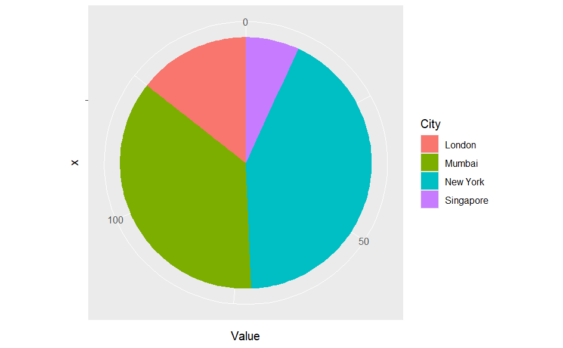

```r
ggplot((data = cityDF), aes(x = "", y = Value, fill = City)) +
  geom_col() +
  coord_polar(theta = "y")
```

You can change the borders.

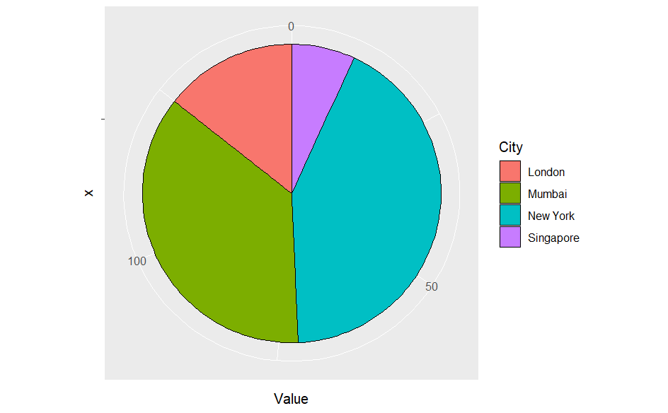

```r
ggplot((data = cityDF), aes(x = "", y = Value, fill = City)) +
  geom_col(color = "black") +
  coord_polar(theta = "y")
```

The ggplot2 package allows a high degree of customization through attributes and specifications. There are many tutorials and cheat sheets on the web. Here is one:

[Data visualization with ggplot2 :: Cheat Sheet](https://rstudio.github.io/cheatsheets/html/data-visualization.html)

As you start using R you would be handling more types of data and want to produce more aesthetically pleasing charts. It is a playground and you should explore.

[R Charts by R Coder](https://r-charts.com/)

[Main Menu](https://htmlpreview.github.io/?https://github.com/argentenum/Rworkshop/blob/master/notebooks/RforHumanities.nb.html)